# Introduction to rspeaksnonmem

Mike K Smith (Mike.K.Smith@Pfizer.com)

2017-04-12

In this notebook we will look at running NONMEM and PsN from R using the R package `rspeaksnonmem`.

### Overview

This demo will show the following steps:

- Running NONMEM and PsN
- Integrating results into a Notebook.

### Step 1: Running NONMEM

First, let’s run a model and knit the results back into this notebook. Note that in the `command` argument to the function we specify the complete path to the NONMEM executable .bat file. This allows you to be very precise about which version of NONMEM you use. If the `clean` argument is non-zero it cleans up the working directory deleting all of the temporary NONMEM files, leaving only the output.

```r
  estimate_NM(command = "c:/nm72/run/nmfe72.bat",
              modelFile = "run0.ctl",
              clean = 1)
```

```
c:/nm72/run/nmfe72.bat "run0.ctl" "run0.lst"
doing nmtran
        1 file(s) copied.
recompiling certain components.
starting wait
ending wait
Exiting lpreddo
Finished compiling fsubs
Completed call to gfcompile.bat
Starting nonmem execution ...
```

```
running command 'c:/nm72/run/nmfe72.bat "run0.ctl" "run0.lst"' had status 1
```

```
[1] "- Cleaning up.."
```

### Step 2: Summarise estimation:

We can now use PsN command `sumo` to summarise the output. Note that here we are not using the `command` argument, but instead we specify the installation directory for Perl / PsN and which PsN version we are using. `rspeaksnonmem` will then create a command based on the directory, `sumo` and version information.

```r
  sumo_PsN(installPath = "c:/strawberry/perl",
           version = "4.6.0",
           lstFile = "run0.lst")
```

```
c:/strawberry/perl/bin/perl c:/strawberry/perl/bin/sumo-4.6.0.pl   "run0.lst"
-----------------------------------------------------------------------

run0.lst

Successful minimization                                           [    OK   ]
No rounding errors                                                [    OK   ]
No zero gradients                                                 [    OK   ]
No final zero gradients                                           [    OK   ]
Hessian not reset                                                 [    OK   ]
No parameter near boundary                                        [    OK   ]
Covariance step                                                   [    OK   ]
Large relative standard errors found                              [ WARNING ]
    PPV_KA                0.673504
Correlations                                                      [    OK   ]

Total run time for model (hours:min:sec):                  00:00:00
Estimation time for subproblem, sum over $EST (seconds):   2.39
Covariance time for subproblem, sum over $EST (seconds):   0.77

Objective function value: 456.3278

ETA shrinkage: 2.7451E+00 1.2913E+01 5.0825E+01 1.0000E+02
Number of observation records: 250
Number of individuals: 32

            THETA                          OMEGA              SIGMA
  POP_CL  0.04809  (0.05312)      PPV_CL  0.2658  (0.1867)
   POP_V    2.919  (0.02548)  OMEGA(2,1)  0.4188  (0.1776)
  POP_KA   0.6628   (0.2245)       PPV_V  0.1139  (0.1735)
RUV_PROP    0.217   (0.1412)      PPV_KA  0.5456  (0.3368)

The relative standard errors for omega and sigma are reported on the approximate
standard deviation scale (SE/variance estimate)/2.
-----------------------------------------------------------------------
[1] 0
```

### Step 3: Model Diagnostics

Next, we might want to produce some model diagnostics using the R package `xpose4`. To do this, we need to create an Xpose database object and then create the diagnostic plots. Xpose needs the run number in order to pick up the $TABLE file outputs from NONMEM.

```r
  runno <- as.numeric(gsub("[a-z]", "", list.files(pattern = "^sdtab")[1]))

  ## ----createXpdb----------------------------------------------------------
  xpdb <- xpose4::xpose.data(runno, quiet = T)
```

```
Looking for NONMEM table files.
    Reading sdtab0
    Reading patab0
    Reading catab0
    Reading cotab0
Table files read.
    Reading run0.phi

Looking for NONMEM simulation table files.
No simulated table files read.
```

```r
  # save(base.xpdb, file='Xpose database.RData')
```

#### DV vs PRED / IPRED

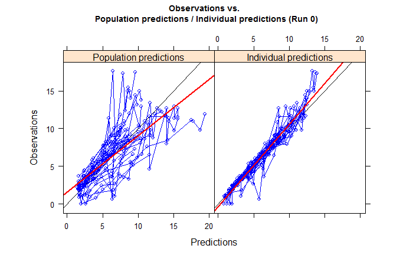

```r
  print(xpose4::dv.vs.pred.ipred(xpdb))
```

#### PRED vs IDV

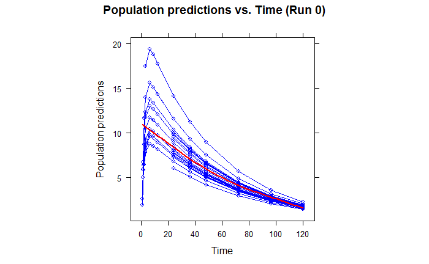

```r
  print(xpose4::pred.vs.idv(xpdb))
```

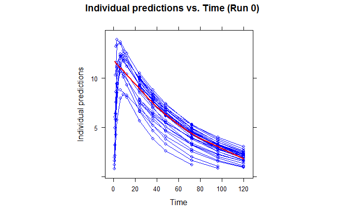

```r
  print(xpose4::ipred.vs.idv(xpdb))
```

#### WRES vs IDV

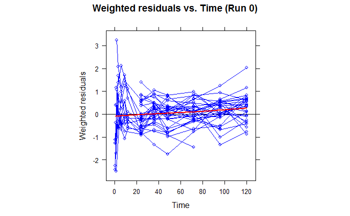

```r
  print(xpose4::wres.vs.idv(xpdb))
```

#### WRES vs PRED

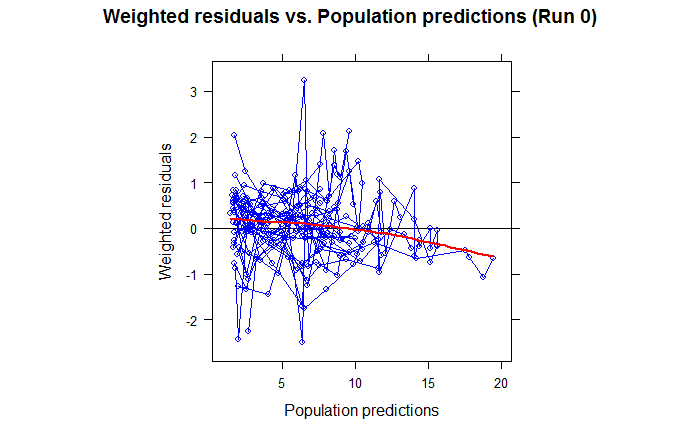

```r
  print(xpose4::wres.vs.pred(xpdb))
```

#### EBEs histogram

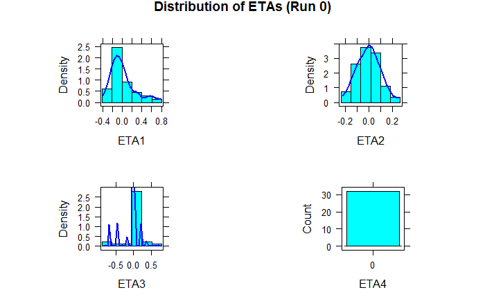

```r
  print(xpose4::ranpar.hist(xpdb))
```

#### Individual Plots

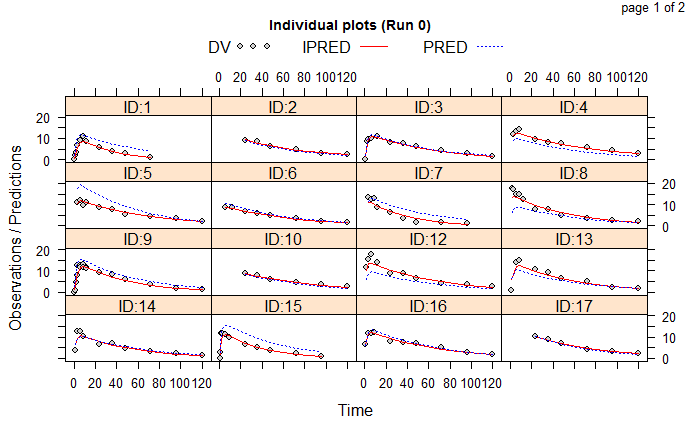

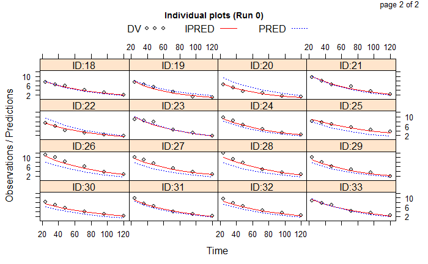

```r
  print(xpose4::ind.plots(xpdb, layout = c(4, 4)))
```

### Step 4: VPC diagnostisc

We may also want to investigate simulation-based diagnostics using the PsN routine VPC. In the call to `VPC_PsN` we have specified the required arguments for VPC (samples, seed) but you can also pass additional arguments to the VPC routine by passing a name-value list to the argument `psnOpts`. `rspeaksnonmem` will check these arguments against the options for VPC and let you know if any are mis-specified. Here the argument `min_points_per_bin` is not a valid option for VPC. (The correct option is `min_points_**in**_bin`.)

```r
VPC_PsN( modelFile='run0.ctl',
         installPath = "c:/strawberry/perl",
         version = "4.6.0",
         working.dir='Run1_VPC',
         samples=100, seed='54321',
         psnOpts=list(lst='run0.lst',
                      auto_bin = '5',
                      min_points_per_bin = '2'))
```

```
min_points_per_bin is not a valid PsN argument for vpc
```

```
c:/strawberry/perl/bin/perl c:/strawberry/perl/bin/vpc-4.6.0.pl   "run0.ctl" -samples=100 -directory="Run1_VPC" -clean=1 -directory="Run1_VPC" -lst_file="run0.lst" -auto_bin="5"
******
Warning: String ICALL.EQ.4 found in modelfile. Simulation statements
will influence NPC/VPC simulations and might produce unwanted results.
Starting 2 NONMEM executions. 2 in parallel.
S:1 .. S:2 .. Waiting for all NONMEM runs to finish:
F:1 .. F:2 ..  done

Reading and formatting DV data. This can take a while...
Reading sample 1 2 4 6 8 10 12 14 16 18 20 22 24 26 28 30 32 34 36 38 40 42 44 46 48 50 52 54 56 58 60 62 64 66 68 70 72 74 76 78 80 82 84 86 88 90 92 94 96 98 100
Done reading and formatting data, finishing run.
Auto binning evaluating N =  5
Auto binning: using 5 bins
Auto binning: bin edges -6.79032258064516,18,60,84,108,132

Running PsN_vpc_plots.R...
vpc done
[1] 0
```

and then use the Xpose function xpose_vpc to plot the result:

[output not shown]

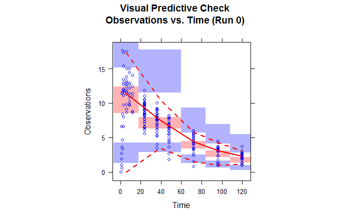

```r
vpcdir <- "Run1_VPC"
vpctab <- file.path(vpcdir,"vpctab")
vpcinfo <- file.path(vpcdir,"vpc_results.csv")
xpose4::xpose.VPC(vpc.info=vpcinfo, vpctab=vpctab)
```